# COM747 Week 7: ML Optimisation and Text Mining

Lecture demonstrations and complete seminar solutions

> **How to use this notebook.** Part A shows gradient descent in plain R so you can see what “training” means. Part B completes the caret tuning sheet (`Exercise(2).docx`). Part C completes the text analysis tutorial and Part D the word2vec tutorial. Several lines in the original sheets don’t run as written; each fix is flagged in an orange box. Put `data.csv` in the same folder.

```r
library(caret); library(C50)
library(tm); library(SnowballC); library(textstem); library(wordcloud)
library(topicmodels); library(sentimentr)
library(word2vec); library(janeaustenr); library(lsa)
```

# Part A: Gradient descent

## A1. One weight

```r
cost  <- function(w) (w - 3)^2 + 1      # the error is lowest at w = 3
slope <- function(w) 2 * (w - 3)        # derivative of the cost

w  <- -4                                # a random starting weight
lr <- 0.1                               # learning rate (step size)
path <- w
for (i in 1:30) {
  w <- w - lr * slope(w)                # step downhill
  path <- c(path, w)
}
round(tail(path, 3), 4)                 # converges towards 3
```

```
## [1] 2.9865 2.9892 2.9913
```

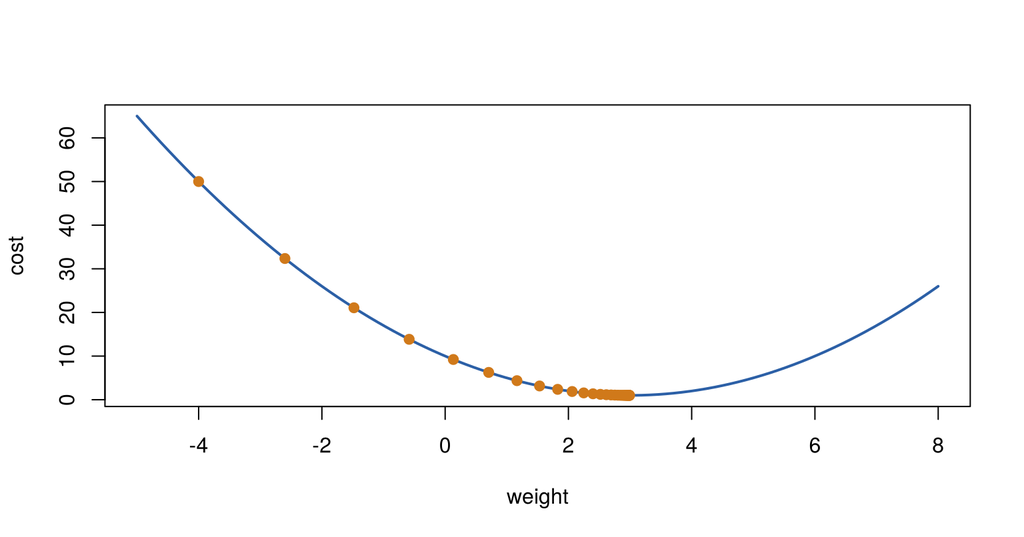

```r
curve(cost, -5, 8, lwd = 2, col = "#2b5fa6", xlab = "weight", ylab = "cost")
points(path, cost(path), pch = 19, col = "#d0791a")
```

```r
# What happens with different learning rates?
run <- function(lr, steps = 30) { w <- -4; for (i in 1:steps) w <- w - lr * slope(w); w }
sapply(c(0.01, 0.1, 0.5, 0.9, 1.1), run)
```

```
## [1]    -0.8183902     2.9913344     3.0000000     2.9913344 -1658.6341966
```

```r
# 0.01 is too slow, 0.5 jumps straight there, 0.9 oscillates, 1.1 diverges
```

## A2. Two weights: fitting a regression line

```r
rundata <- read.csv("rundata.csv")
x <- as.numeric(scale(rundata$FirstRun)); y <- as.numeric(scale(rundata$SecondRun))   # standardised
m <- 0; b <- 0; lr <- 0.05; mse <- c()
for (i in 1:200) {
  e  <- m * x + b - y                 # errors with the current weights
  m  <- m - lr * mean(2 * e * x)      # gradient of MSE with respect to m
  b  <- b - lr * mean(2 * e)          # gradient of MSE with respect to b
  mse <- c(mse, mean(e^2))
}
c(m = m, b = b)
```

```
##            m            b
## 9.762012e-01 2.777510e-16
```

```r
coef(lm(y ~ x))                        # the closed-form OLS answer: the same
```

```
##  (Intercept)            x
## 5.292185e-16 9.762012e-01
```

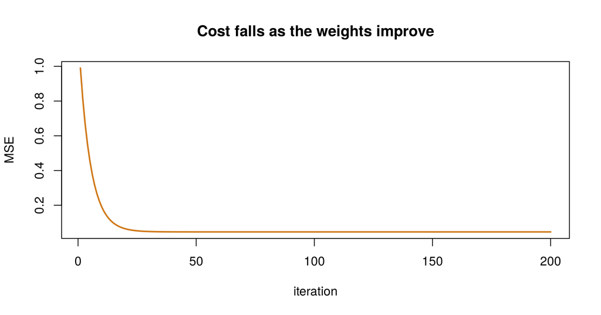

```r
plot(mse, type = "l", lwd = 2, col = "#d0791a", xlab = "iteration", ylab = "MSE", main = "Cost falls as the weights improve")
```

# Part B: ML optimisation with caret

```r
modelLookup("C5.0")   # the three tunable hyperparameters: trials, model, winnow
```

```
##   model parameter                 label forReg forClass probModel
## 1  C5.0    trials # Boosting Iterations  FALSE     TRUE      TRUE
## 2  C5.0     model            Model Type  FALSE     TRUE      TRUE
## 3  C5.0    winnow                Winnow  FALSE     TRUE      TRUE
```

```r
data <- read.csv("data.csv")
data <- data[, c(2:32)]                     # drop id and the empty X column
data$diagnosis <- factor(data$diagnosis)    # caret needs a factor label
set.seed(1)
partition    <- createDataPartition(data$diagnosis, p = 0.7, list = FALSE)
trainingData <- data[partition, ]
testData     <- data[-partition, ]
```

## B1. The default grid

```r
set.seed(1)
model <- train(diagnosis ~ ., method = "C5.0", data = trainingData)
model            # 12 combinations: model (2) x winnow (2) x trials (3), each resampled 25 times
```

```
## C5.0
##
## 399 samples
##  30 predictor
##   2 classes: 'B', 'M'
##
## No pre-processing
## Resampling: Bootstrapped (25 reps)
## Summary of sample sizes: 399, 399, 399, 399, 399, 399, ...
## Resampling results across tuning parameters:
##
##   model  winnow  trials  Accuracy   Kappa
##   rules  FALSE    1      0.9423598  0.8767648
##   rules  FALSE   10      0.9565357  0.9066968
##   rules  FALSE   20      0.9560059  0.9052199
##   rules   TRUE    1      0.9397130  0.8705498
##   rules   TRUE   10      0.9481804  0.8885149
##   rules   TRUE   20      0.9522759  0.8974462
##   tree   FALSE    1      0.9387319  0.8692309
##   tree   FALSE   10      0.9560911  0.9055810
##   tree   FALSE   20      0.9586400  0.9110602
##   tree    TRUE    1      0.9387567  0.8684865
##   tree    TRUE   10      0.9504626  0.8938533
##   tree    TRUE   20      0.9492638  0.8912104
##
## Accuracy was used to select the optimal model using the largest value.
## The final values used for the model were trials = 20, model = tree and winnow
##  = FALSE.
```

```r
model$bestTune
```

```
##   trials model winnow
## 3     20  tree  FALSE
```

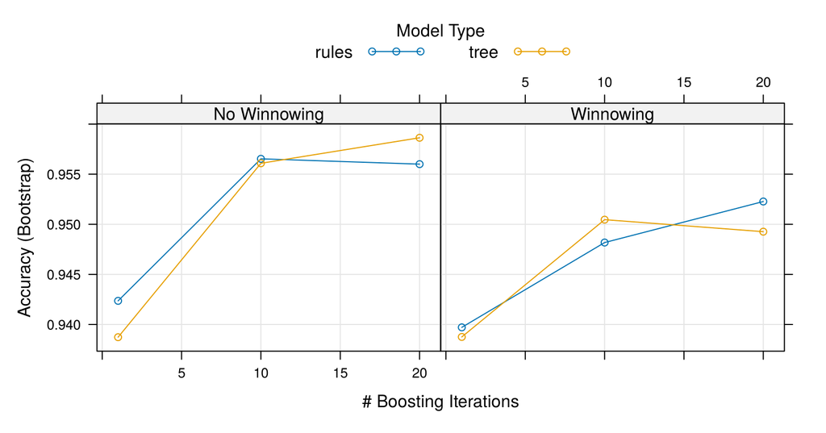

```r
plot(model)      # accuracy for each setting
```

**Which settings perform best?** A boosted *tree* with 20 trials and winnow off has the highest resampled accuracy (95.9%). But look at the spread: most settings are within one percentage point, so the choice matters less than it first seems.

## B2. Selecting on kappa

```r
set.seed(1)
model_k <- train(diagnosis ~ ., method = "C5.0", data = trainingData, metric = "Kappa")
model_k$bestTune
```

```
##   trials model winnow
## 3     20  tree  FALSE
```

## B3. The simplest model within one standard error

```r
control <- trainControl(method = "cv", number = 10, selectionFunction = "oneSE")
set.seed(1)
model_1se <- train(diagnosis ~ ., method = "C5.0", data = trainingData, trControl = control)
model_1se$bestTune   # fewer trials: simpler, and almost as accurate
```

```
##   trials model winnow
## 8     10 rules  FALSE
```

## B4. A custom grid

```r
customGrid <- expand.grid(model = c("rules", "tree"), trials = c(20, 25, 30, 35, 40), winnow = c(FALSE))
customGrid           # 10 combinations to test
```

```
##    model trials winnow
## 1  rules     20  FALSE
## 2   tree     20  FALSE
## 3  rules     25  FALSE
## 4   tree     25  FALSE
## 5  rules     30  FALSE
## 6   tree     30  FALSE
## 7  rules     35  FALSE
## 8   tree     35  FALSE
## 9  rules     40  FALSE
## 10  tree     40  FALSE
```

```r
set.seed(1)
model_grid <- train(diagnosis ~ ., method = "C5.0", data = trainingData, tuneGrid = customGrid)
model_grid
```

```
## C5.0
##
## 399 samples
##  30 predictor
##   2 classes: 'B', 'M'
##
## No pre-processing
## Resampling: Bootstrapped (25 reps)
## Summary of sample sizes: 399, 399, 399, 399, 399, 399, ...
## Resampling results across tuning parameters:
##
##   model  trials  Accuracy   Kappa
##   rules  20      0.9560059  0.9052199
##   rules  25      0.9557296  0.9049201
##   rules  30      0.9579626  0.9097117
##   rules  35      0.9593962  0.9127929
##   rules  40      0.9596431  0.9134546
##   tree   20      0.9586400  0.9110602
##   tree   25      0.9583557  0.9106350
##   tree   30      0.9583634  0.9106043
##   tree   35      0.9584114  0.9107036
##   tree   40      0.9598356  0.9137831
##
## Tuning parameter 'winnow' was held constant at a value of FALSE
## Accuracy was used to select the optimal model using the largest value.
## The final values used for the model were trials = 40, model = tree and winnow
##  = FALSE.
```

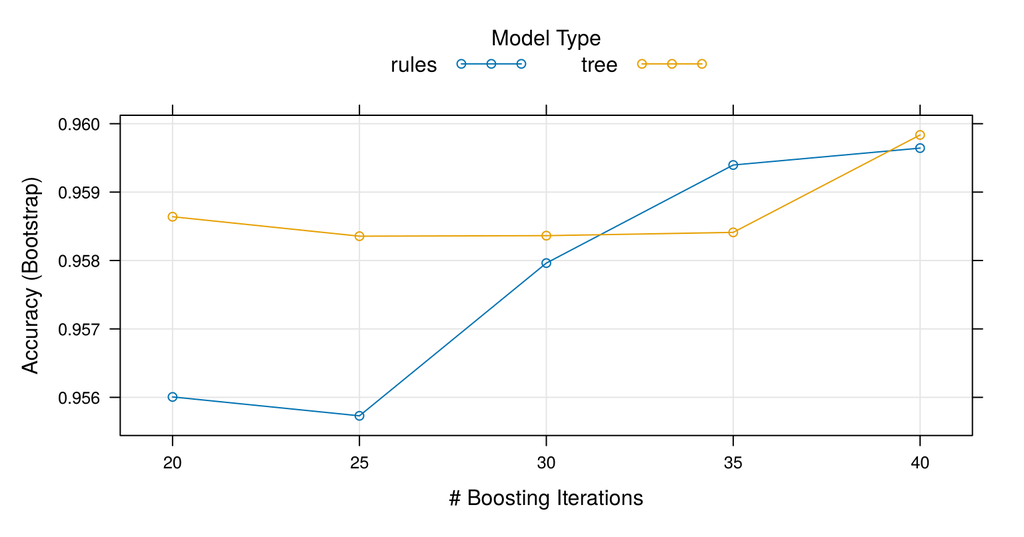

```r
plot(model_grid)
```

## B5. My own grid: k-NN with many values of k

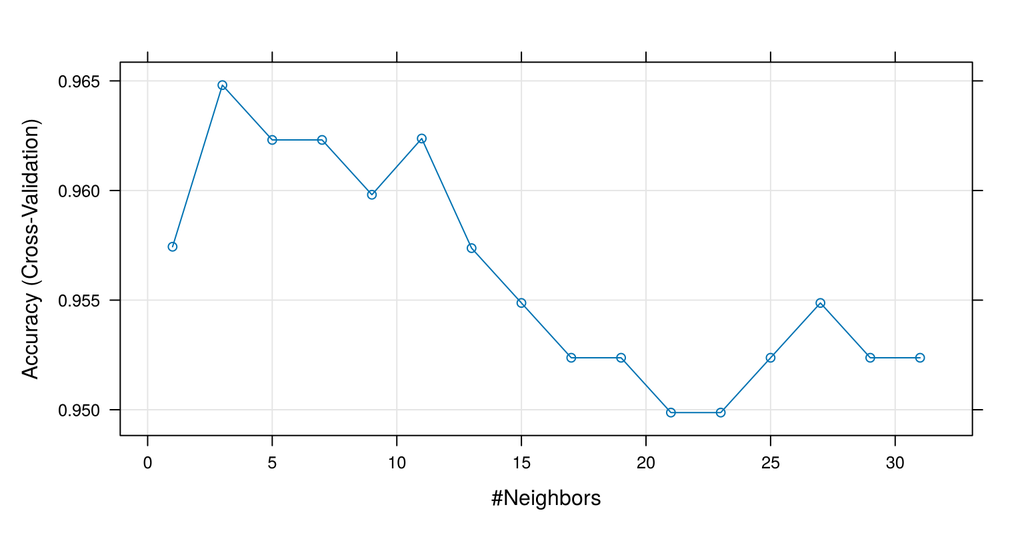

```r
set.seed(1)
knn_model <- train(diagnosis ~ ., method = "knn", data = trainingData,
                   preProcess = c("center", "scale"),
                   tuneGrid = expand.grid(k = seq(1, 31, by = 2)),
                   trControl = trainControl(method = "cv", number = 10))
plot(knn_model)
```

```r
knn_model$bestTune
```

```
##   k
## 2 3
```

## B6. How do the chosen models do on the test set?

```r
test_acc <- sapply(list(default = model, kappa = model_k, oneSE = model_1se, grid = model_grid, knn = knn_model),
                   function(m) mean(predict(m, testData) == testData$diagnosis))
round(test_acc, 4)
```

```
## default   kappa   oneSE    grid     knn
##  0.9529  0.9529  0.9529  0.9529  0.9647
```

The test-set differences are 1–2 cases out of 170. Tuning squeezes out small gains on the training folds; on new data the models are practically tied. Report the resampled accuracy *and* the test accuracy, and prefer the simpler model when they are close.

# Part C: Text analysis tutorial

## C1. Stemming and lemmatisation

```r
words <- c("Learning", "Learned", "Learn", "Learning")
wordStem(words)
```

```
## [1] "Learn" "Learn" "Learn" "Learn"
```

```r
wordStem(c("trouble", "troubled", "troublesome", "troubles"))   # "troubl" is not a real word
```

```
## [1] "troubl"     "troubl"     "troublesom" "troubl"
```

```r
wordStem(c("running", "runs", "ran", "studies", "studying"))     # irregular "ran" is untouched
```

```
## [1] "run"   "run"   "ran"   "studi" "studi"
```

```r
lemmatize_words(c("trouble", "troubled", "troublesome", "troubles"))
```

```
## [1] "trouble"     "trouble"     "troublesome" "trouble"
```

```r
lemmatize_words(c("running", "runs", "ran", "studies", "better"))  # dictionary forms: ran -> run, better -> good
```

```
## [1] "run"   "run"   "run"   "study" "good"
```

## C2. Stop words

```r
head(stopwords("en"), 30)      # the kind of words we usually remove
```

```
##  [1] "i"          "me"         "my"         "myself"     "we"
##  [6] "our"        "ours"       "ourselves"  "you"        "your"
## [11] "yours"      "yourself"   "yourselves" "he"         "him"
## [16] "his"        "himself"    "she"        "her"        "hers"
## [21] "herself"    "it"         "its"        "itself"     "they"
## [26] "them"       "their"      "theirs"     "themselves" "what"
```

```r
length(stopwords("en"))
```

```
## [1] 174
```

```r
someText <- c("I love programming and specifically data science because of the statistics and ML")
removeWords(someText, stopwords("en"))
```

```
## [1] "I love programming  specifically data science    statistics  ML"
```

“I” survives because `removeWords` is case-sensitive and the stop list is lowercase. Lowercase first: `removeWords(tolower(someText), stopwords("en"))`.

```r
removeWords(tolower(someText), stopwords("en"))
```

```
## [1] " love programming  specifically data science    statistics  ml"
```

## C3. Document-term matrix

```r
txt <- c("I liked this programming course and liked the lectures",
         "The course and lectures are useful as a primer for programming",
         "I liked the programming aspects of the course")
txtCorpus  <- VCorpus(VectorSource(txt))
docTermMat <- DocumentTermMatrix(txtCorpus)   # lowercases and keeps words of 3+ letters by default
inspect(docTermMat)
```

```
## <<DocumentTermMatrix (documents: 3, terms: 12)>>
## Non-/sparse entries: 21/15
## Sparsity           : 42%
## Maximal term length: 11
## Weighting          : term frequency (tf)
## Sample             :
##     Terms
## Docs and are aspects course for lectures liked primer programming the
##    1   1   0       0      1   0        1     2      0           1   1
##    2   1   1       0      1   1        1     0      1           1   1
##    3   0   0       1      1   0        0     1      0           1   2
```

## C4. Bar plot of term frequencies

The tutorial writes `wordFreq <- colSums(txt)`, but `txt` is still the character vector of sentences, so this fails. Convert the DTM to a matrix first.

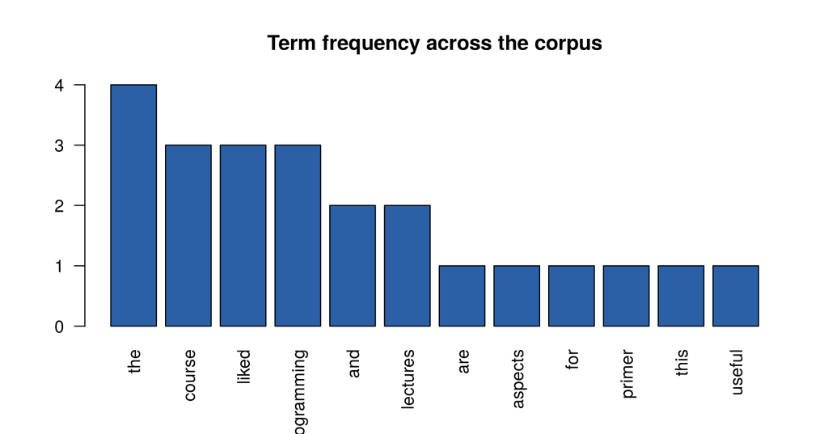

```r
dtm_matrix <- as.matrix(docTermMat)
wordFreq <- colSums(dtm_matrix)                 # or apply(dtm_matrix, 2, sum)
sorted <- wordFreq[order(wordFreq, decreasing = TRUE)]   # order() returns the positions in sorted order
barplot(sorted, las = 2, col = "#2b5fa6", main = "Term frequency across the corpus")
```

```r
findFreqTerms(docTermMat, 3)                    # terms used at least 3 times
```

```
## [1] "course"      "liked"       "programming" "the"
```

## C5. Word cloud

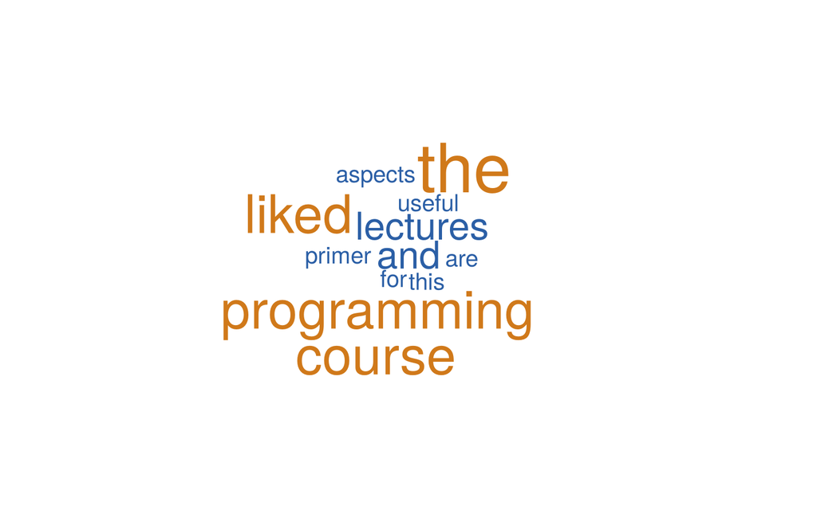

```r
set.seed(1)   # word placement is random
wordcloud(words = names(wordFreq), freq = wordFreq, min.freq = 1, colors = c("#2b5fa6", "#d0791a"))
```

```r
# ?wordcloud   (lower-case w: R is case-sensitive, so ?Wordcloud finds nothing)
```

```r
# A bigger text: a whole Jane Austen novel, cleaned
emma <- austen_books()$text[austen_books()$book == "Emma"]
corp <- VCorpus(VectorSource(emma))
corp <- tm_map(corp, content_transformer(tolower))
corp <- tm_map(corp, removePunctuation)
corp <- tm_map(corp, removeWords, c(stopwords("en"), "said", "will", "must", "much", "every", "one"))
freq <- sort(colSums(as.matrix(DocumentTermMatrix(corp))), decreasing = TRUE)
head(freq, 10)
```

```
##    emma     mrs    miss harriet   thing   think  weston  little    well   never
##     744     681     583     385     383     381     377     360     348     344
```

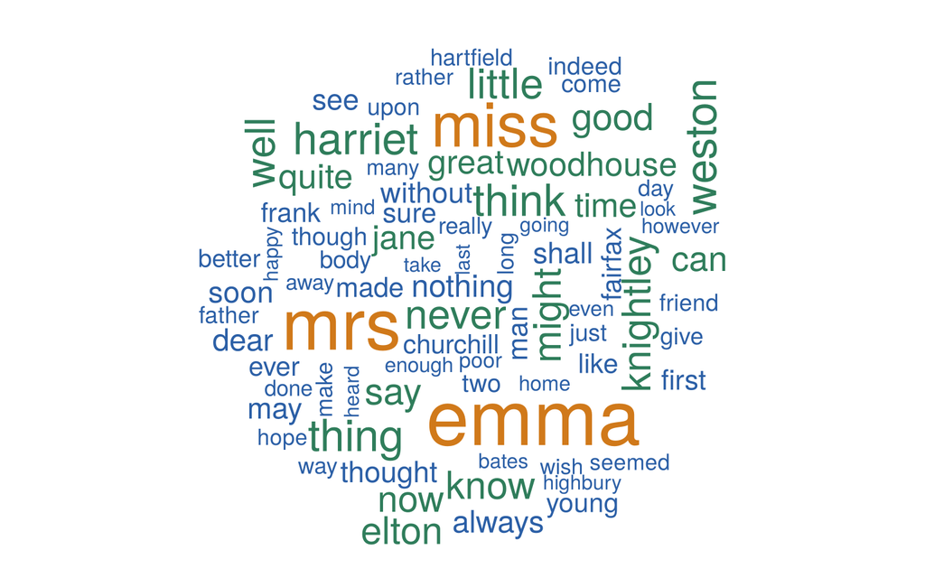

```r
set.seed(1)
wordcloud(names(freq), freq, max.words = 80, colors = c("#2b5fa6", "#2f7d5b", "#d0791a"))
```

## C6. Sparse terms, associations and dictionaries

```r
inspect(removeSparseTerms(docTermMat, 0.4))     # keep terms present in at least 60% of documents
```

```
## <<DocumentTermMatrix (documents: 3, terms: 6)>>
## Non-/sparse entries: 15/3
## Sparsity           : 17%
## Maximal term length: 11
## Weighting          : term frequency (tf)
## Sample             :
##     Terms
## Docs and course lectures liked programming the
##    1   1      1        1     2           1   1
##    2   1      1        1     0           1   1
##    3   0      1        0     1           1   2
```

```r
findAssocs(docTermMat, "lectures", 0.4)         # terms whose counts correlate with "lectures"
```

```
## $lectures
##    and    are    for primer   this useful
##    1.0    0.5    0.5    0.5    0.5    0.5
```

```r
inspect(DocumentTermMatrix(txtCorpus, list(dictionary = c("lectures", "course", "liked"))))
```

```
## <<DocumentTermMatrix (documents: 3, terms: 3)>>
## Non-/sparse entries: 7/2
## Sparsity           : 22%
## Maximal term length: 8
## Weighting          : term frequency (tf)
## Sample             :
##     Terms
## Docs course lectures liked
##    1      1        1     2
##    2      1        1     0
##    3      1        0     1
```

## C7. tf-idf

```r
tf    <- DocumentTermMatrix(txtCorpus)
tfIdf <- weightTfIdf(tf, normalize = FALSE)
inspect(tfIdf)
```

```
## <<DocumentTermMatrix (documents: 3, terms: 12)>>
## Non-/sparse entries: 12/24
## Sparsity           : 67%
## Maximal term length: 11
## Weighting          : term frequency - inverse document frequency (tf-idf)
## Sample             :
##     Terms
## Docs       and      are  aspects course      for  lectures     liked   primer
##    1 0.5849625 0.000000 0.000000      0 0.000000 0.5849625 1.1699250 0.000000
##    2 0.5849625 1.584963 0.000000      0 1.584963 0.5849625 0.0000000 1.584963
##    3 0.0000000 0.000000 1.584963      0 0.000000 0.0000000 0.5849625 0.000000
##     Terms
## Docs     this   useful
##    1 1.584963 0.000000
##    2 0.000000 1.584963
##    3 0.000000 0.000000
```

```r
# by hand, as on the slide:
1 * log2(3 / 1)   # a word used once in one document only: 1.585
```

```
## [1] 1.584963
```

```r
2 * log2(3 / 2)   # "liked" twice in doc 1, present in 2 of 3 documents: 1.170
```

```
## [1] 1.169925
```

## C8. Topic modelling

The slide has `data('AssociatedPress’)` with a curly closing quote copied from PowerPoint, which R rejects. Use straight quotes.

```r
data("AssociatedPress")
AssociatedPress                                 # 2,246 news articles x 10,473 terms
```

```
## <<DocumentTermMatrix (documents: 2246, terms: 10473)>>
## Non-/sparse entries: 302031/23220327
## Sparsity           : 99%
## Maximal term length: 18
## Weighting          : term frequency (tf)
```

```r
topicModelling <- LDA(AssociatedPress, k = 4, control = list(seed = 1))   # seed for reproducibility
terms(topicModelling, 10)
```

```
##       Topic 1     Topic 2      Topic 3     Topic 4
##  [1,] "people"    "soviet"     "percent"   "i"
##  [2,] "i"         "government" "million"   "court"
##  [3,] "two"       "president"  "new"       "state"
##  [4,] "police"    "united"     "year"      "years"
##  [5,] "officials" "states"     "billion"   "case"
##  [6,] "years"     "military"   "bush"      "new"
##  [7,] "new"       "party"      "market"    "attorney"
##  [8,] "city"      "people"     "last"      "two"
##  [9,] "three"     "two"        "president" "judge"
## [10,] "miles"     "minister"   "company"   "last"
```

## C9. Sentiment

```r
s <- sentiment(c("I am very happy", "I am not very happy",
                 "The lectures were useful but the room was cold",
                 "This module is great and I love the labs", "The test was terrible"))
s
```

```
##    element_id sentence_id word_count   sentiment
## 1:          1           1          4  0.67500000
## 2:          2           1          5 -0.06708204
## 3:          3           1          9 -0.37483333
## 4:          4           1          9  0.41666667
## 5:          5           1          4 -0.37500000
```

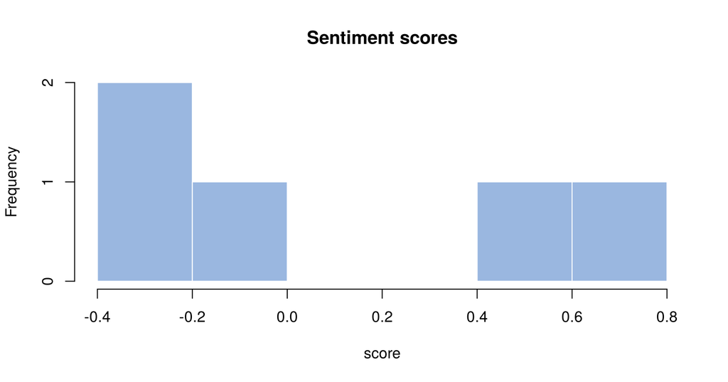

```r
hist(s$sentiment, col = "#9ab7e0", border = "white", main = "Sentiment scores", xlab = "score")
```

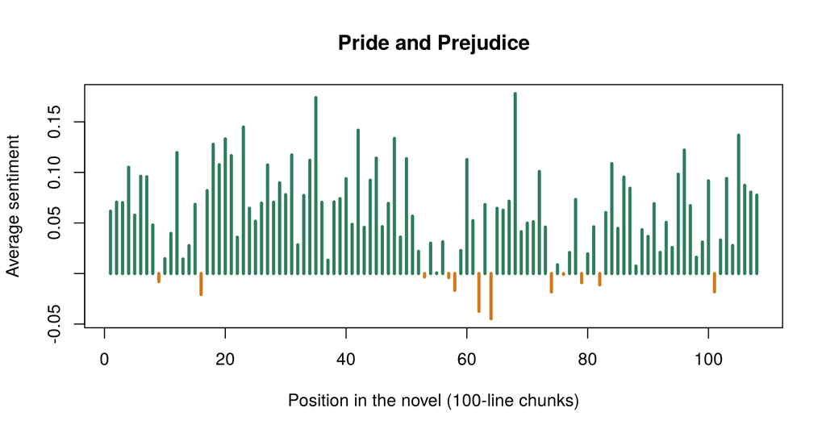

```r
# Sentiment through a whole novel, in chunks of 100 lines
pp <- austen_books()$text[austen_books()$book == "Pride & Prejudice"]
pp <- pp[pp != ""]
chunk <- ceiling(seq_along(pp) / 100)
by_chunk <- tapply(sentiment_by(get_sentences(pp))$ave_sentiment, chunk, mean)
plot(by_chunk, type = "h", col = ifelse(by_chunk > 0, "#2f7d5b", "#d0791a"), lwd = 3,
     xlab = "Position in the novel (100-line chunks)", ylab = "Average sentiment", main = "Pride and Prejudice")
```

# Part D: Word2vec tutorial

```r
set.seed(1)
txt <- austen_books()
model <- word2vec(x = txt$text[txt$book == "Sense & Sensibility"], type = "cbow", dim = 15, iter = 20)
embeddings <- as.matrix(model)
dim(embeddings)                                 # one 15-number vector per word
```

```
## [1] 2141   15
```

```r
vocabulary <- summary(model, type = "vocabulary")
length(vocabulary)                              # ~2,141 words; anything else is "out of vocabulary"
```

```
## [1] 2141
```

```r
embeddings["hope", ]
```

```
##  [1] -1.60046327  0.61341596  0.31606185 -0.21661575  0.87463671  0.64992392
##  [7]  0.84419388  0.79554814 -0.52416593  0.05208664 -0.26710984 -1.38133717
## [13] -2.43742633  0.22128877  1.06562316
```

```r
predict(model, c("Lucy"), type = "nearest", top_n = 10)
```

```
## $Lucy
##    term1      term2 similarity rank
## 1   Lucy   Marianne  0.9080365    1
## 2   Lucy     Edward  0.9017263    2
## 3   Lucy     Elinor  0.8980926    3
## 4   Lucy    husband  0.8776104    4
## 5   Lucy Willoughby  0.8698395    5
## 6   Lucy    Ferrars  0.8641254    6
## 7   Lucy   daughter  0.8535123    7
## 8   Lucy  Charlotte  0.8498729    8
## 9   Lucy         he  0.8393313    9
## 10  Lucy      Fanny  0.8373209   10
```

```r
predict(model, c("Lucy", "man", "woman"), type = "nearest", top_n = 5)
```

```
## $Lucy
##   term1      term2 similarity rank
## 1  Lucy   Marianne  0.9080365    1
## 2  Lucy     Edward  0.9017263    2
## 3  Lucy     Elinor  0.8980926    3
## 4  Lucy    husband  0.8776104    4
## 5  Lucy Willoughby  0.8698395    5
##
## $man
##   term1  term2 similarity rank
## 1   man person  0.9551122    1
## 2   man  woman  0.9460255    2
## 3   man   girl  0.9248852    3
## 4   man   lady  0.8913358    4
## 5   man    men  0.8860091    5
##
## $woman
##   term1  term2 similarity rank
## 1 woman    man  0.9460255    1
## 2 woman   girl  0.9382117    2
## 3 woman  proud  0.9301490    3
## 4 woman person  0.9256257    4
## 5 woman  young  0.8751100    5
```

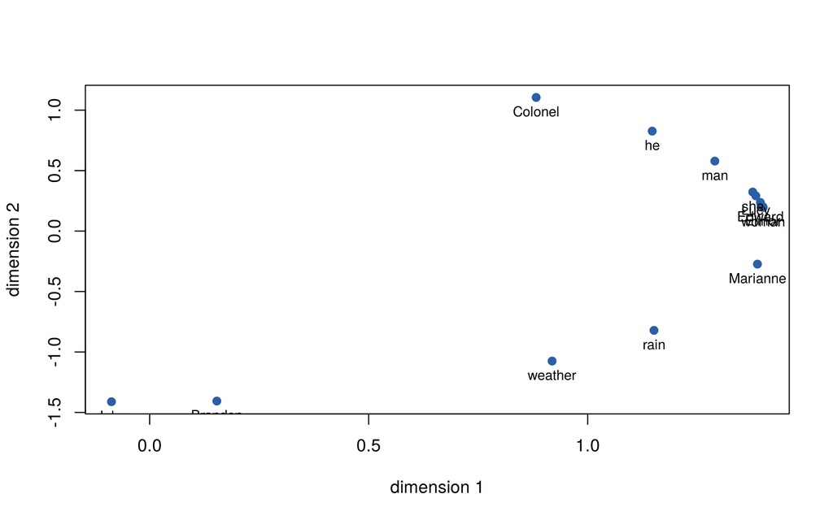

```r
set.seed(1)
model2 <- word2vec(x = txt$text[txt$book == "Sense & Sensibility"], type = "cbow", dim = 2, iter = 20)
words <- c("John", "Lucy", "Edward", "Marianne", "Elinor", "woman", "man", "she", "he", "Colonel", "Brandon", "rain", "weather")
emb2 <- as.data.frame(predict(model2, words, type = "embedding"))
plot(emb2$V1, emb2$V2, pch = 19, col = "#2b5fa6", xlab = "dimension 1", ylab = "dimension 2")
text(emb2$V1, emb2$V2, labels = row.names(emb2), pos = 1, cex = 0.8)
```

Two dimensions are far too few to capture meaning, so treat this plot as an illustration only. The 15-dimensional model above is what you should use for similarity.

```r
euclidean <- function(a, b) sqrt(sum((a - b)^2))
euclidean(embeddings["rain", ], embeddings["weather", ])
```

```
## [1] 2.681003
```

```r
euclidean(embeddings["Brandon", ], embeddings["Colonel", ])
```

```
## [1] 4.908472
```

```r
cosine(embeddings["Lucy", ], embeddings["Elinor", ])     # lsa::cosine: 1 = same direction
```

```
##           [,1]
## [1,] 0.8065704
```

```r
cor(embeddings["Brandon", ], embeddings["Colonel", ])
```

```
## [1] 0.208764
```

```r
cor(embeddings["weather", ], embeddings["rain", ])
```

```
## [1] 0.761113
```

```r
# Vector arithmetic: hurry + walk ~ ?
vector <- embeddings["hurry", ] + embeddings["walk", ]
predict(model, vector, type = "nearest", top_n = 10)
```

```
##          term similarity rank
## 1       party  0.9995577    1
## 2       arise  0.9992342    2
## 3       downs  0.9990107    3
## 4        look  0.9988871    4
## 5      valley  0.9986635    5
## 6     anybody  0.9978334    6
## 7        shop  0.9978167    7
## 8  melancholy  0.9973412    8
## 9     through  0.9972235    9
## 10       shew  0.9969363   10
```

# Summary

| Task | R |
| --- | --- |
| Hyperparameters | `modelLookup("C5.0")` |
| Grid search | `train(..., tuneGrid = expand.grid(...))`, `metric = "Kappa"` |
| Simpler model | `trainControl(selectionFunction = "oneSE")` |
| Clean text | `tolower`, `removePunctuation`, `removeWords(stopwords("en"))`, `wordStem`, `lemmatize_words` |
| Count words | `DocumentTermMatrix(VCorpus(VectorSource(txt)))`, `findFreqTerms`, `findAssocs` |
| Weight | `weightTfIdf(dtm, normalize = FALSE)` |
| Topics | `topicmodels::LDA(dtm, k)`, `terms()` |
| Sentiment | `sentimentr::sentiment()` |
| Embeddings | `word2vec()`, `predict(type = "nearest")`, `lsa::cosine()` |